# AGO_Ovar229_MO39212_Fut_Anal

Anh Nguyen Duc

2021-06-21

## 0.1 Supportive techinical resource

- https://pages.github.roche.com/successR/successR/index.html
- https://cran.r-project.org/web/packages/bpp/index.html
- https://onlinelibrary.wiley.com/doi/full/10.1002/pst.1764
- https://www.tandfonline.com/doi/full/10.1080/10543406.2014.972508
- https://www.sciencedirect.com/science/article/pii/0197245686900048

## 0.2 Plan

- Consider various futility thresholds on the scale of conditional probability (function post_power in bpp package) for both PFS and OS
  - Using the formula in Lema A.1. of https://www.tandfonline.com/doi/full/10.1080/10543406.2014.972508,
  - whereby $\theta$ is always assumed to be the log hazard ratio in the power calculation.
- Consider various pairs of ``true’’ underlying HR for OS and PFS.
- Consider various number of OS events (also calculate the associated expected months from FPI to reaching target OS event number).
- Go through each of these combinations / scenarios and calculate
  - Probability of GO decision (false / true contingent on the underlying pairs of OS/PFS HR).
  - Probability of GO decision & with positive read-out (a subset of the above).
  - Expected read-out time (under the current pairs of ``true’’ OS/PFS HR).
  - To avoid simulation one can first consider again the formula from Lemma A.1. of https://www.tandfonline.com/doi/full/10.1080/10543406.2014.972508, where by
    - For both OS and PFS, let $d_{fin}$ be the event number at the final / primary analysis, $d_{int}$ be the event number at the futility analysis, $\theta_{suc}$ be the efficacy boundary on the log hazard ratio scale at the final / primary analysis, $\theta_{int}$ be the observed log HR at the futility analysis and $d_2=d_{fin}-d_{int}$. Finally let $\theta$ be the assumed log HR that the events accumulated after the futility analysis will follow, which is always considered to be the log HR used in power calculation. Further more let $\gamma$ be the futility boundary on the conditional power scale.
    - Given these notations and Lemma A.1. formula we have:
      $$\begin{align*}
      & CP_{\theta}\ge\gamma\\
      \Leftrightarrow & \theta_{int}\le d_{int}^{-1}\left(d_{fin}\theta_{suc}-2\sqrt{d_{fin}}\Phi^{-1}\left(\gamma\right)-d_2\theta\right)
      \end{align*}$$
    - For each of the true underlying log HR $\theta_0$ we have

    $$\left(
    \begin{array}{c}
    \theta_{int} \\
    \theta_{fin}
    \end{array}
    \right)
    \sim\mathcal{N}
    \left(
    \left(
    \begin{array}{c}
    \theta_0 \\
    \theta_0
    \end{array}
    \right),\
    \left(
    \begin{array}{cc}
    \frac{4}{d_{int}} & \frac{4}{d_{fin}}\\
    \frac{4}{d_{fin}} & \frac{4}{d_{fin}}
    \end{array}
    \right)
    \right)$$
    - With this one could then calculate the following quantities
      - $P_{\theta_0}\left(CP_{\theta}\ge\gamma\right)$
      - $P_{\theta_0}\left(CP_{\theta}\ge\gamma\bigcap\theta_{fin}\le\theta_{suc}\right)$
      - $P_{\theta_0}\left(\theta_{fin}\le\theta_{suc}\mid CP_{\theta}\ge\gamma\right)$
- Caveat of current proposal and possible extensions
  - In the simulation we ignore the intrinsic correlation between PFS and OS as well as the potential to recycle $\alpha$ between the endpoints.
  - The use of predicive probability would be mentioned as a potential modification with the caveat concerning the difficulty in choosing a prior.
  - An efficacy stopping boundary could also be added.

```r
## Trial setup -----------------------------
fpi <- as.Date('2018-08-01')

mOS_ctr <- 15
alp_OS  <- .045 # two-sided
pow_OS  <- 0.8

mPFS_ctr<- 6.5
alp_PFS <- .005 # two-sided
pow_PFS <- 0.92

final_OS_ev <- 391
final_PFS_ev<- 547

rr <- 1 # Pla : Atz

# below data is from file MO39212_Amd1_20210119_V4_0_CI_PST_revRocheLegal_BWJlegal_20210301_20210304_ba_revNC_PST_revNC.doc / Attachment 8 (p22)
tmp_accrualIntensity <-  c(0, 100, 266, 332, 399, 465, 531, 598, 664) %>% diff
tmp_accrualTime <- (((as.Date(c('2018-08-01', '2020-05-01', '2021-04-01', '2021-07-01',
                         '2021-08-01', '2021-10-01', '2021-12-01', '2022-02-01',
                         '2022-03-01')) - fpi) %>% as.numeric)/30.4375) %>% round
tmp_accrualTime_diff <- tmp_accrualTime %>% diff

accrualIntensity <- accrualTime <- NULL
accrualTime <- 0

for(id in 1:length(tmp_accrualIntensity)) {
  accrualIntensity <- c(accrualIntensity,
                        rep(tmp_accrualIntensity[id]/tmp_accrualTime_diff[id], times=tmp_accrualTime_diff[id]) )
  accrualTime <- c(accrualTime, (tmp_accrualTime[id]+1):tmp_accrualTime[id+1])

} # end of for(id in 1:length(tmp_accrualIntensity))

drop_out_time <- 9 # this would generally only affect timeline

## Simulation / Calculation setup -----------------------------

# true underlying HRs
hrOS  <- c(0.75, 0.8, .95)
hrPFS <- c(0.70, 0.8, .95)

# number of OS events at which the futility analyis is to take place
futi_OS_ev <- c(175, 200, 225, 250)

# futility threshold on (currently) conditional probability scale
futi_threshold <- c(0.2, .25, 0.3, 0.35, .4)

settings <- expand.grid('hrOS'=hrOS, 'hrPFS'=hrPFS, 'futi_OS_ev'=futi_OS_ev,
                        'futi_threshold'=futi_threshold)
settings <- settings[order(settings$hrOS, settings$hrPFS, settings$futi_OS_ev, settings$futi_threshold),]

deg_OS <- getDesignGroupSequential(kMax=1, alpha=alp_OS/2,  sided = 1, beta=1-pow_OS)

sam_OS <- deg_OS %>% getSampleSizeSurvival(median2 = mOS_ctr, hazardRatio = 0.75, allocationRatioPlanned = rr, accrualTime = accrualTime, accrualIntensity = accrualIntensity, dropoutRate1 = .05, dropoutRate2 = .05, dropoutTime = drop_out_time)

sam_OS %>% summary
```

```
## Sample size calculation for a survival endpoint
##
## Fixed sample analysis.
## The sample size was calculated for a two-sample logrank test (one-sided),
## H0: hazard ratio = 1, H1: hazard ratio = 0.75, control median(2) = 15, power 80%.
##
## Stage                               Fixed
## Efficacy boundary (z-value scale)   2.005
## Number of subjects                  664.0
## Number of events                      392
## Analysis time                        57.7
## Expected study duration              57.7
## One-sided local significance level 0.0225
## Efficacy boundary (t)               0.817
##
## Legend:
##   (t): approximate treatment effect scale
```

```r
deg_PFS<- getDesignGroupSequential(kMax=1, alpha=alp_PFS/2, sided = 1, beta=1-pow_PFS)

sam_PFS<- deg_PFS %>% getSampleSizeSurvival(median2 = mPFS_ctr, hazardRatio = 0.70, allocationRatioPlanned = rr, accrualTime = accrualTime, accrualIntensity = accrualIntensity, dropoutRate1 = .05, dropoutRate2 = .05, dropoutTime = drop_out_time)

theta_suc_OS <- sam_OS$criticalValuesEffectScale %>% as.numeric %>% log
theta_suc_PFS<- sam_PFS$criticalValuesEffectScale %>% as.numeric %>% log

set.seed(21)
out <- NULL

for (id in 1:nrow(settings)) {

  # get expected number of PFS events at each of the above OS events
  tmp <- deg_OS %>% getPowerSurvival(median2 = mOS_ctr, hazardRatio = settings$hrOS[id], allocationRatioPlanned = rr, accrualTime = accrualTime, accrualIntensity = accrualIntensity, dropoutRate1 = .05, dropoutRate2 = .05, dropoutTime = drop_out_time, maxNumberOfSubjects = accrualIntensity %>% sum, maxNumberOfEvents = settings$futi_OS_ev[id])

  time_to_OS<- tmp$analysisTime %>% ceiling

  OS_calen  <- (fpi + time_to_OS * 30.4375) %>% format("%Y-%b") %>% as.character

  event_PFS <- (getEventProbabilities(time = time_to_OS %>% as.numeric,
                                     accrualTime = accrualTime, accrualIntensity = accrualIntensity,
                                     lambda2 = log(2)/mPFS_ctr,
                                     hazardRatio = settings$hrPFS[id], allocationRatioPlanned = rr,
                                     dropoutRate1 = .05, dropoutRate2 = .05, dropoutTime = 12)$overallEventProbabilities * sum(accrualIntensity) )%>% ceiling

  d2_OS <- final_OS_ev  - settings$futi_OS_ev[id]
  d2_PFS<- final_PFS_ev - event_PFS

  tmp_OS <- (1/settings$futi_OS_ev[id]) * (final_OS_ev * theta_suc_OS -
                                           2*sqrt(final_OS_ev)*qnorm(settings$futi_threshold[id])-
                                           d2_OS*0.75%>%log)

  tmp_PFS <- (1/event_PFS) * (final_PFS_ev * theta_suc_PFS -
                                           2*sqrt(final_PFS_ev)*qnorm(settings$futi_threshold[id])-
                                           d2_PFS*0.70%>%log)

  prob_cp_ge_futi_threshold_OS <- pnorm(q = tmp_OS, mean = settings$hrOS[id]%>%log,
                                        sd = 2/sqrt(settings$futi_OS_ev[id]), lower.tail = T)

  prob_cp_ge_futi_threshold_PFS<- pnorm(q = tmp_PFS, mean = settings$hrPFS[id]%>%log,
                                        sd = 2/sqrt(event_PFS), lower.tail = T)


  prob_cp_ge_futi_threshold_OS_and_pos_OS <- pmvnorm(lower=c(-Inf, -Inf),
                                                     upper=c(tmp_OS, theta_suc_OS),
                                                     mean =rep(settings$hrOS[id]%>%log, 2),
                                                     sigma=rbind(
                                                       c(4/settings$futi_OS_ev[id], 4/final_OS_ev),
                                                       c(4/final_OS_ev,             4/final_OS_ev)
                                                       )
                                                     )

  prob_cp_ge_futi_threshold_PFS_and_pos_PFS <- pmvnorm(lower=c(-Inf, -Inf),
                                                       upper=c(tmp_PFS, theta_suc_PFS),
                                                       mean =rep(settings$hrPFS[id]%>%log, 2),
                                                       sigma=rbind(
                                                       c(4/event_PFS,    4/final_PFS_ev),
                                                       c(4/final_PFS_ev, 4/final_PFS_ev)
                                                       )
                                                    )

  out <- rbind(out,
               c('OS_time'=time_to_OS, 'OS_date'=OS_calen, 'PFS_ev'= event_PFS,
                 'P_go_OS'=prob_cp_ge_futi_threshold_OS %>% round(digits=2),
                 'P_go_pos_OS'=prob_cp_ge_futi_threshold_OS_and_pos_OS %>% round(digits=2),
                 'P_pos_OS_cond_go_OS'=(prob_cp_ge_futi_threshold_OS_and_pos_OS/
                                       prob_cp_ge_futi_threshold_OS) %>% round(digits=2),
                 'P_go_PFS'=prob_cp_ge_futi_threshold_PFS %>% round(digits=2),
                 'P_go_pos_PFS'=prob_cp_ge_futi_threshold_PFS_and_pos_PFS %>% round(digits=2),
                 'P_pos_PFS_cond_go_PFS'=(prob_cp_ge_futi_threshold_PFS_and_pos_PFS/
                                       prob_cp_ge_futi_threshold_PFS) %>% round(digits=2)
                 ))

} # end of for (id in 1:nrow(settings))
```

```r
cbind(settings, out) %>% kable(digits=2) %>% print
```

|  | hrOS | hrPFS | futi_OS_ev | futi_threshold | OS_time | OS_date | PFS_ev | P_go_OS | P_go_pos_OS | P_pos_OS_cond_go_OS | P_go_PFS | P_go_pos_PFS | P_pos_PFS_cond_go_PFS |
| --- | --- | --- | --- | --- | --- | --- | --- | --- | --- | --- | --- | --- | --- |
| 1 | 0.75 | 0.70 | 175 | 0.20 | 41 | 2021-Dec | 294 | 0.99 | 0.8 | 0.8 | 1 | 0.92 | 0.92 |
| 37 | 0.75 | 0.70 | 175 | 0.25 | 41 | 2021-Dec | 294 | 0.99 | 0.8 | 0.81 | 1 | 0.92 | 0.92 |
| 73 | 0.75 | 0.70 | 175 | 0.30 | 41 | 2021-Dec | 294 | 0.98 | 0.8 | 0.81 | 1 | 0.92 | 0.92 |
| 109 | 0.75 | 0.70 | 175 | 0.35 | 41 | 2021-Dec | 294 | 0.97 | 0.79 | 0.82 | 0.99 | 0.92 | 0.92 |
| 145 | 0.75 | 0.70 | 175 | 0.40 | 41 | 2021-Dec | 294 | 0.95 | 0.79 | 0.83 | 0.99 | 0.91 | 0.93 |
| 10 | 0.75 | 0.70 | 200 | 0.20 | 43 | 2022-Mar | 343 | 0.99 | 0.8 | 0.81 | 1 | 0.92 | 0.92 |
| 46 | 0.75 | 0.70 | 200 | 0.25 | 43 | 2022-Mar | 343 | 0.98 | 0.8 | 0.81 | 1 | 0.92 | 0.92 |
| 82 | 0.75 | 0.70 | 200 | 0.30 | 43 | 2022-Mar | 343 | 0.97 | 0.8 | 0.82 | 0.99 | 0.92 | 0.92 |
| 118 | 0.75 | 0.70 | 200 | 0.35 | 43 | 2022-Mar | 343 | 0.96 | 0.79 | 0.83 | 0.99 | 0.92 | 0.93 |
| 154 | 0.75 | 0.70 | 200 | 0.40 | 43 | 2022-Mar | 343 | 0.94 | 0.79 | 0.84 | 0.98 | 0.91 | 0.93 |
| 19 | 0.75 | 0.70 | 225 | 0.20 | 44 | 2022-Apr | 369 | 0.99 | 0.8 | 0.81 | 1 | 0.92 | 0.92 |
| 55 | 0.75 | 0.70 | 225 | 0.25 | 44 | 2022-Apr | 369 | 0.98 | 0.8 | 0.82 | 0.99 | 0.92 | 0.92 |
| 91 | 0.75 | 0.70 | 225 | 0.30 | 44 | 2022-Apr | 369 | 0.96 | 0.8 | 0.83 | 0.99 | 0.92 | 0.93 |
| 127 | 0.75 | 0.70 | 225 | 0.35 | 44 | 2022-Apr | 369 | 0.95 | 0.79 | 0.84 | 0.98 | 0.92 | 0.93 |
| 163 | 0.75 | 0.70 | 225 | 0.40 | 44 | 2022-Apr | 369 | 0.93 | 0.78 | 0.85 | 0.98 | 0.91 | 0.93 |
| 28 | 0.75 | 0.70 | 250 | 0.20 | 46 | 2022-Jun | 414 | 0.98 | 0.8 | 0.81 | 0.99 | 0.92 | 0.92 |
| 64 | 0.75 | 0.70 | 250 | 0.25 | 46 | 2022-Jun | 414 | 0.97 | 0.8 | 0.82 | 0.99 | 0.92 | 0.93 |
| 100 | 0.75 | 0.70 | 250 | 0.30 | 46 | 2022-Jun | 414 | 0.96 | 0.8 | 0.83 | 0.99 | 0.92 | 0.93 |
| 136 | 0.75 | 0.70 | 250 | 0.35 | 46 | 2022-Jun | 414 | 0.94 | 0.79 | 0.84 | 0.98 | 0.92 | 0.94 |
| 172 | 0.75 | 0.70 | 250 | 0.40 | 46 | 2022-Jun | 414 | 0.91 | 0.78 | 0.86 | 0.97 | 0.91 | 0.94 |
| 4 | 0.75 | 0.80 | 175 | 0.20 | 41 | 2021-Dec | 304 | 0.99 | 0.8 | 0.8 | 0.97 | 0.43 | 0.45 |
| 40 | 0.75 | 0.80 | 175 | 0.25 | 41 | 2021-Dec | 304 | 0.99 | 0.8 | 0.81 | 0.95 | 0.43 | 0.46 |
| 76 | 0.75 | 0.80 | 175 | 0.30 | 41 | 2021-Dec | 304 | 0.98 | 0.8 | 0.81 | 0.92 | 0.43 | 0.47 |
| 112 | 0.75 | 0.80 | 175 | 0.35 | 41 | 2021-Dec | 304 | 0.97 | 0.79 | 0.82 | 0.89 | 0.43 | 0.48 |
| 148 | 0.75 | 0.80 | 175 | 0.40 | 41 | 2021-Dec | 304 | 0.95 | 0.79 | 0.83 | 0.85 | 0.43 | 0.5 |
| 13 | 0.75 | 0.80 | 200 | 0.20 | 43 | 2022-Mar | 354 | 0.99 | 0.8 | 0.81 | 0.94 | 0.43 | 0.46 |
| 49 | 0.75 | 0.80 | 200 | 0.25 | 43 | 2022-Mar | 354 | 0.98 | 0.8 | 0.81 | 0.91 | 0.43 | 0.48 |
| 85 | 0.75 | 0.80 | 200 | 0.30 | 43 | 2022-Mar | 354 | 0.97 | 0.8 | 0.82 | 0.87 | 0.43 | 0.5 |
| 121 | 0.75 | 0.80 | 200 | 0.35 | 43 | 2022-Mar | 354 | 0.96 | 0.79 | 0.83 | 0.83 | 0.43 | 0.52 |
| 157 | 0.75 | 0.80 | 200 | 0.40 | 43 | 2022-Mar | 354 | 0.94 | 0.79 | 0.84 | 0.78 | 0.43 | 0.54 |

[output cut: 150 more lines]

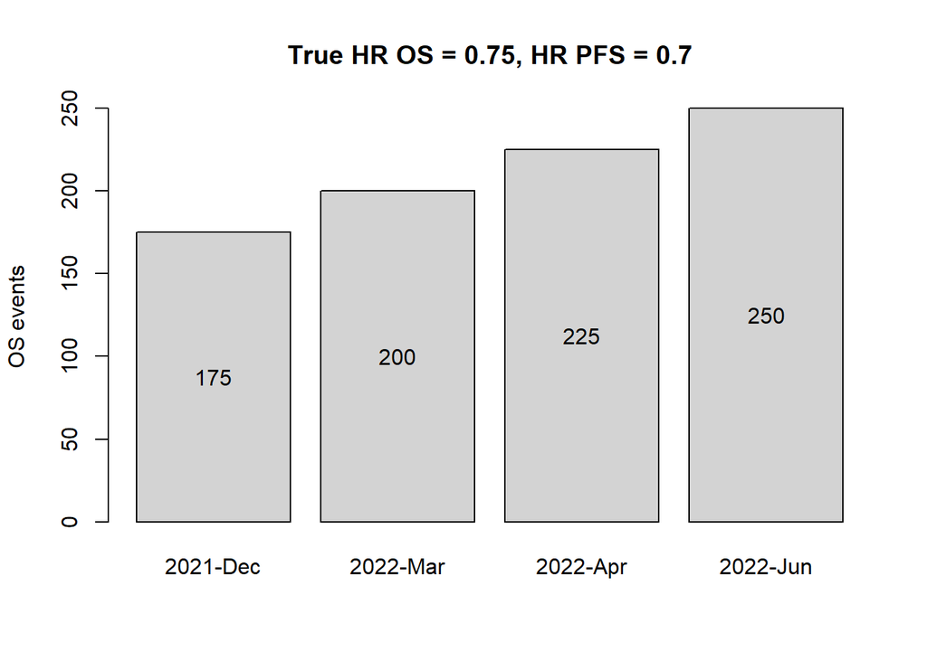

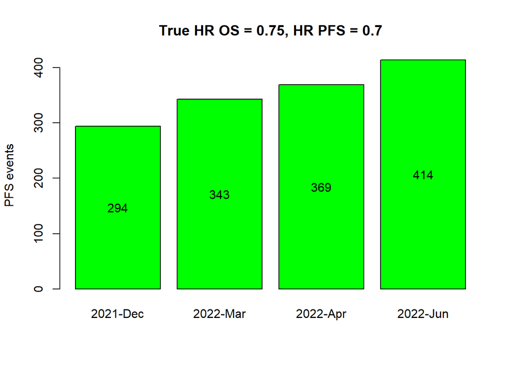

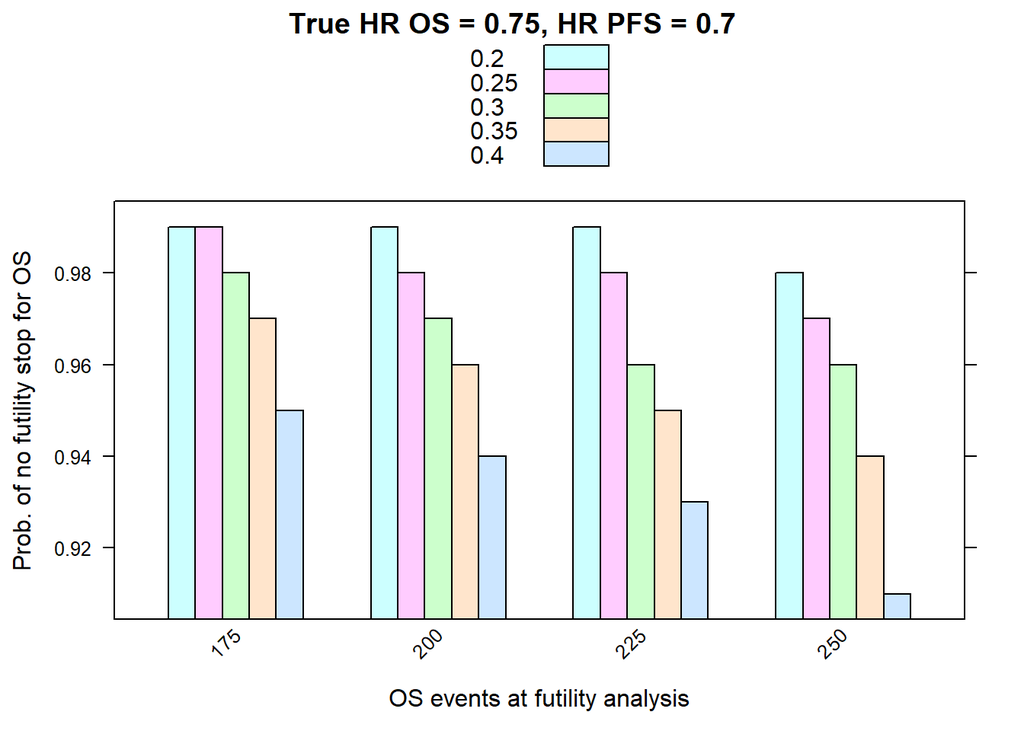

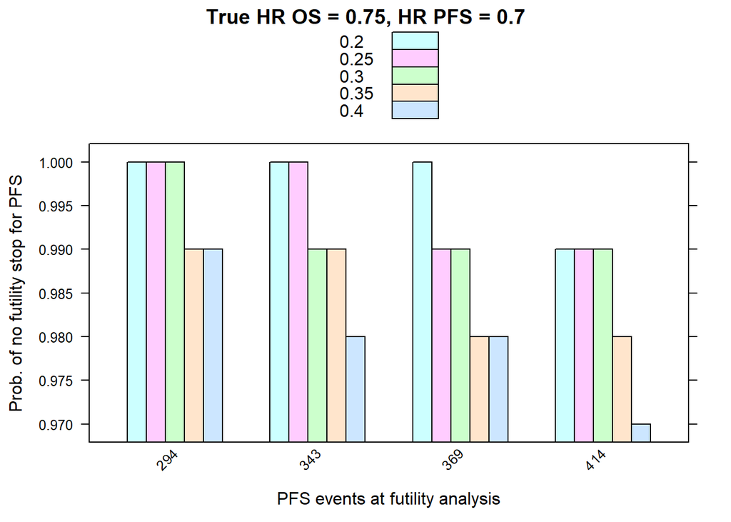

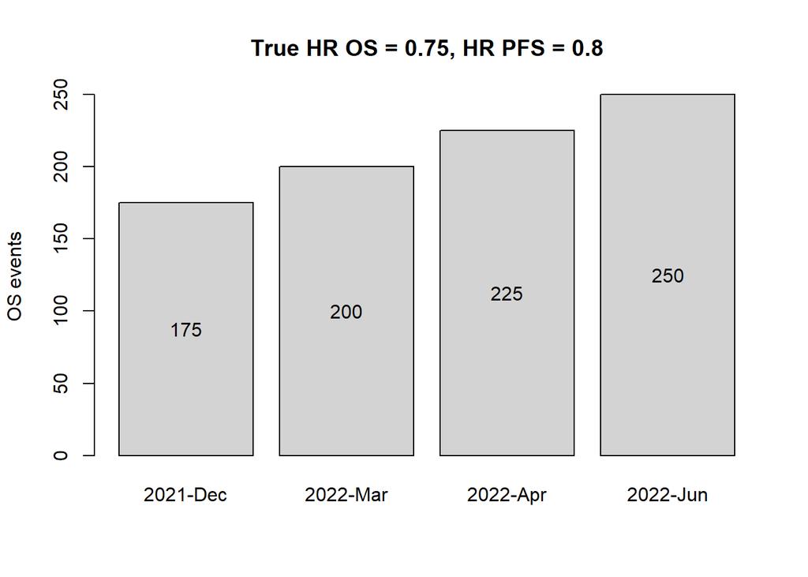

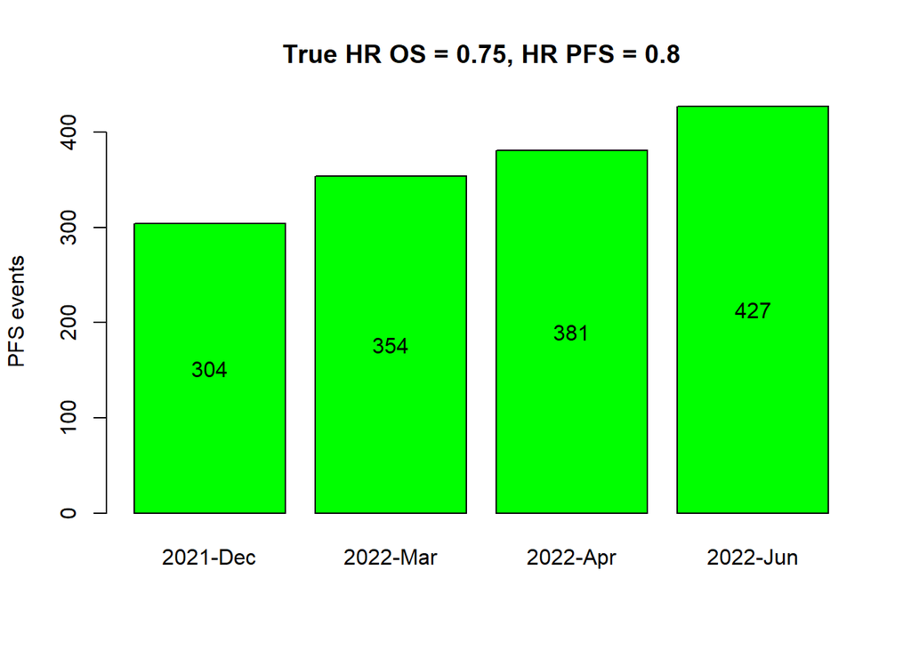

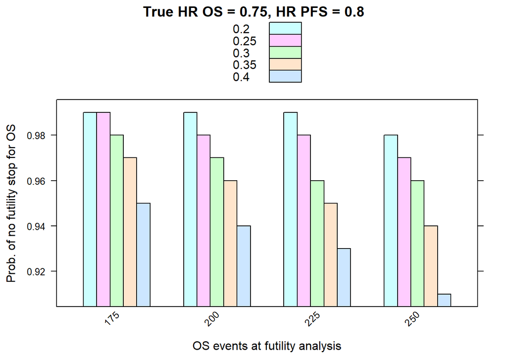

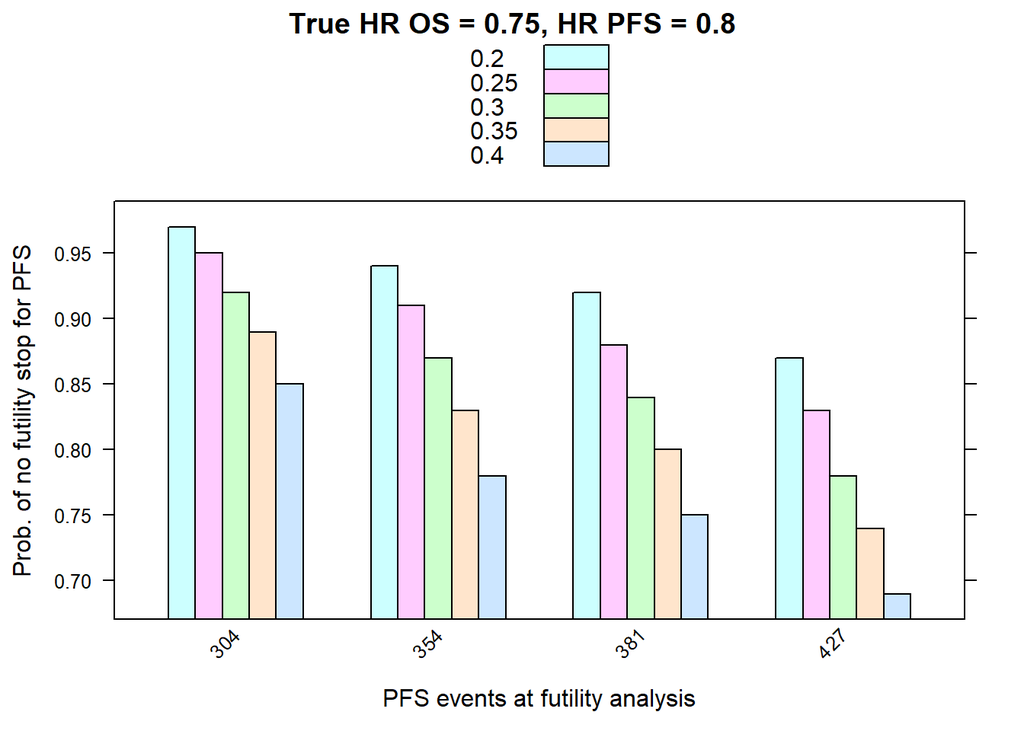

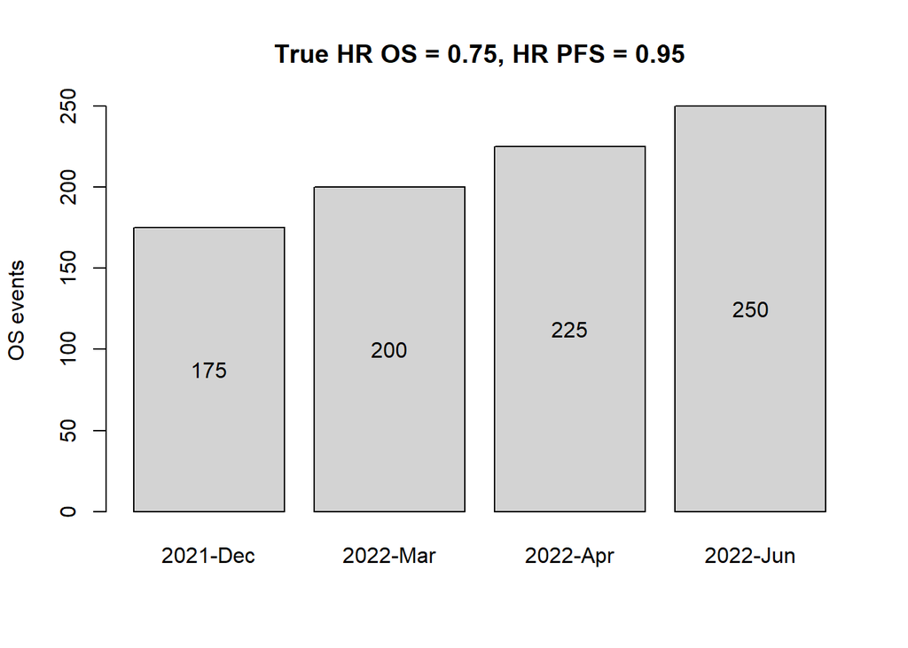

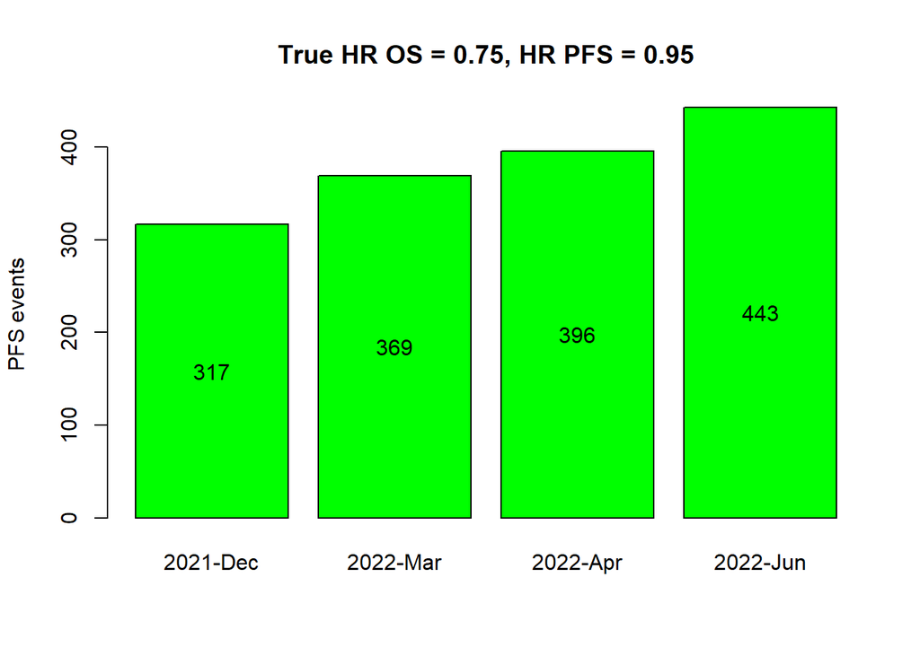

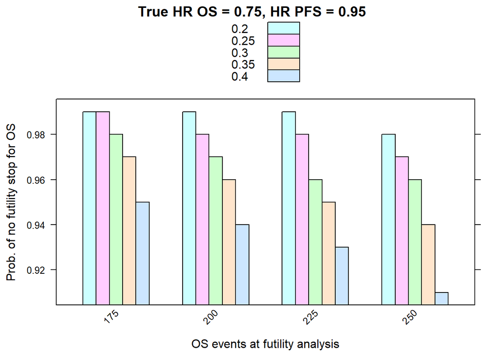

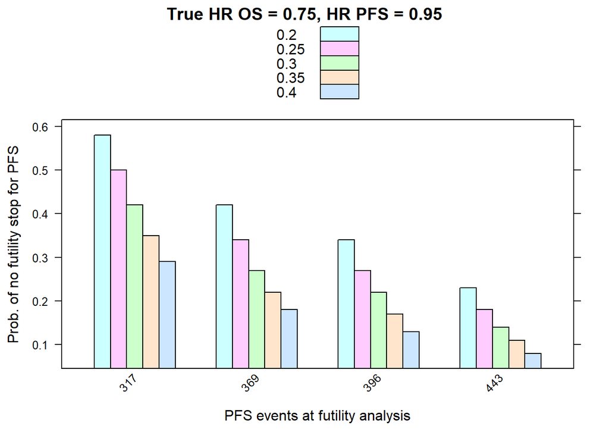

[24 more figures not shown]

```r
out <- out %>% as.data.frame
library(lattice)

for (hr_os in hrOS) {

  for (hr_pfs in hrPFS) {
    tmp_settings <- settings[which(settings$hrOS==hr_os & settings$hrPFS==hr_pfs),]
    tmp_out      <- out[which(settings$hrOS==hr_os & settings$hrPFS==hr_pfs),]
    tmp <- cbind(tmp_settings, tmp_out)

    #par(mfrow=c(4,1))

    with(tmp, {
      bp<-barplot(height = futi_OS_ev %>% unique, names.arg = OS_date %>% unique,  col='lightgray',
                  ylab = 'OS events', main=paste0('True HR OS = ', hr_os, ', HR PFS = ', hr_pfs))
      text(x=bp, y = futi_OS_ev%>%unique/2, labels = futi_OS_ev%>%unique)

      bp<-barplot(height = PFS_ev %>% unique %>% as.character %>% as.numeric,
                  names.arg = OS_date %>% unique,  col='green', ylab = 'PFS events',
                  main=paste0('True HR OS = ', hr_os, ', HR PFS = ', hr_pfs))
      text(x=bp, y = (PFS_ev%>%unique%>%as.character %>% as.numeric)/2,
           labels = PFS_ev%>%unique%>%as.character %>% as.numeric)

      })

    barchart(I(P_go_OS %>% as.character %>% as.numeric)~I(futi_OS_ev%>%as.factor), data=tmp, groups=futi_threshold,
             scales=list(x=list(rot=45,cex=0.8)), auto.key=T,
             xlab='OS events at futility analysis', ylab='Prob. of no futility stop for OS',
             main=paste0('True HR OS = ', hr_os, ', HR PFS = ', hr_pfs)) %>% print

    barchart(I(P_go_PFS %>% as.character %>% as.numeric)~I(PFS_ev), data=tmp, groups=futi_threshold,
             scales=list(x=list(rot=45,cex=0.8)), auto.key=T,
             xlab='PFS events at futility analysis', ylab='Prob. of no futility stop for PFS',
             main=paste0('True HR OS = ', hr_os, ', HR PFS = ', hr_pfs)) %>% print

  } # end of for (hr_pfs in hrPFS)

} # end of for (hr_os in hrOS)
```

```r
## get results for green, blue and yellow scenario


# out_summary_low <- out_summary_upp <- list()

for (id0 in 1:length(futi_OS_ev)) {

  out_summary_low <- out_summary_upp <- matrix(NA, nrow=length(hrOS), ncol=length(futi_threshold))

  for (id in 1:length(futi_threshold)) {

    id_green <- which((settings$hrOS==0.75 | settings$hrPFS==0.70) & settings$futi_threshold==futi_threshold[id] & settings$futi_OS_ev==futi_OS_ev[id0])
    id_blue  <- which(((settings$hrOS==0.80 & settings$hrPFS!=0.70) |
                      (settings$hrOS!=0.75 & settings$hrPFS==0.80)) & settings$futi_threshold==futi_threshold[id] & settings$futi_OS_ev==futi_OS_ev[id0])
    id_yellow<- which((settings$hrOS==0.95 & settings$hrPFS==0.95) & settings$futi_threshold==futi_threshold[id] & settings$futi_OS_ev==futi_OS_ev[id0])
    out_green <- out[id_green,]
    tmp_green <- c(pmax(out_green$P_go_OS %>% as.character %>% as.numeric, out_green$P_go_PFS %>% as.character %>% as.numeric),
                   pmin(1, out_green$P_go_OS %>% as.character %>% as.numeric + out_green$P_go_PFS %>% as.character %>% as.numeric)
                  )


    out_blue <- out[id_blue,]
    tmp_blue <- c(pmax(out_blue$P_go_OS %>% as.character %>% as.numeric, out_blue$P_go_PFS %>% as.character %>% as.numeric),
                   pmin(1, out_blue$P_go_OS %>% as.character %>% as.numeric + out_blue$P_go_PFS %>% as.character %>% as.numeric)
                  )

    out_yellow <- out[id_yellow,]
    tmp_yellow <- c(pmax(out_yellow$P_go_OS %>% as.character %>% as.numeric, out_yellow$P_go_PFS %>% as.character %>% as.numeric),
                   pmin(1, out_yellow$P_go_OS %>% as.character %>% as.numeric + out_yellow$P_go_PFS %>% as.character %>% as.numeric)
                  )


    out_summary_low[1, id] <- min(tmp_green)
    out_summary_upp[1, id] <- max(tmp_green)

    out_summary_low[2, id] <- min(tmp_blue)
    out_summary_upp[2, id] <- max(tmp_blue)

    out_summary_low[3, id] <- min(tmp_yellow)
    out_summary_upp[3, id] <- max(tmp_yellow)
  } # end of for (id in 1:length(futi_threshold))
  out_summary_low %>% kable(col.names = futi_threshold, caption=paste0('Lower bound for Prob of trial continuation, OS ev = ', futi_OS_ev[id0])) %>% print
  out_summary_upp %>% kable(col.names = futi_threshold, caption=paste0('Upper bound for Prob of trial continuation, OS ev = ', futi_OS_ev[id0])) %>% print
} # end of for (id0 in 1:length(futi_OS_ev))
```

Lower bound for Prob of trial continuation, OS ev = 175

| 0.2 | 0.25 | 0.3 | 0.35 | 0.4 |
| --- | --- | --- | --- | --- |
| 0.99 | 0.99 | 0.98 | 0.97 | 0.95 |
| 0.98 | 0.96 | 0.94 | 0.91 | 0.88 |
| 0.83 | 0.76 | 0.68 | 0.61 | 0.53 |

Upper bound for Prob of trial continuation, OS ev = 175

| 0.2 | 0.25 | 0.3 | 0.35 | 0.4 |
| --- | --- | --- | --- | --- |
| 1 | 1 | 1 | 1 | 1.00 |
| 1 | 1 | 1 | 1 | 1.00 |
| 1 | 1 | 1 | 1 | 0.89 |

Lower bound for Prob of trial continuation, OS ev = 200

| 0.2 | 0.25 | 0.3 | 0.35 | 0.4 |
| --- | --- | --- | --- | --- |
| 0.99 | 0.98 | 0.97 | 0.96 | 0.94 |
| 0.95 | 0.93 | 0.90 | 0.86 | 0.82 |
| 0.75 | 0.67 | 0.59 | 0.52 | 0.44 |

Upper bound for Prob of trial continuation, OS ev = 200

| 0.2 | 0.25 | 0.3 | 0.35 | 0.4 |
| --- | --- | --- | --- | --- |
| 1 | 1 | 1.00 | 1.0 | 1.00 |
| 1 | 1 | 1.00 | 1.0 | 1.00 |
| 1 | 1 | 0.94 | 0.8 | 0.67 |

Lower bound for Prob of trial continuation, OS ev = 225

| 0.2 | 0.25 | 0.3 | 0.35 | 0.4 |
| --- | --- | --- | --- | --- |
| 0.99 | 0.98 | 0.96 | 0.95 | 0.93 |
| 0.94 | 0.91 | 0.87 | 0.83 | 0.78 |
| 0.67 | 0.59 | 0.51 | 0.44 | 0.37 |

Upper bound for Prob of trial continuation, OS ev = 225

| 0.2 | 0.25 | 0.3 | 0.35 | 0.4 |
| --- | --- | --- | --- | --- |
| 1 | 1.00 | 1.00 | 1.00 | 1.00 |
| 1 | 1.00 | 1.00 | 1.00 | 1.00 |
| 1 | 0.93 | 0.78 | 0.66 | 0.55 |

Lower bound for Prob of trial continuation, OS ev = 250

| 0.2 | 0.25 | 0.3 | 0.35 | 0.4 |
| --- | --- | --- | --- | --- |
| 0.98 | 0.97 | 0.96 | 0.94 | 0.91 |
| 0.89 | 0.85 | 0.81 | 0.76 | 0.71 |
| 0.59 | 0.51 | 0.44 | 0.37 | 0.31 |

Upper bound for Prob of trial continuation, OS ev = 250

| 0.2 | 0.25 | 0.3 | 0.35 | 0.4 |
| --- | --- | --- | --- | --- |
| 1.00 | 1.00 | 1.00 | 1.0 | 1.00 |
| 1.00 | 1.00 | 1.00 | 1.0 | 1.00 |
| 0.87 | 0.73 | 0.61 | 0.5 | 0.41 |